Desmond Ajayi

R00194774

Cat and Dog classifier

# Let import the dataset

```python
# setup kaggle, so that I can get the dataset directly
!pip install -q kaggle
!mkdir -p ~/.kaggle
!cp kaggle.json ~/.kaggle/
```

```python
#Libraries Import
from PIL import Image
from os import listdir
import pandas as pd
import matplotlib.pyplot as plt
import numpy as np
import random
import cv2
import os
from fastai.imports import *
```

```python
# Download full original dataset from kaggle
!kaggle competitions download -c dogs-vs-cats
```

```python
# lets view the files
!ls
```

```
kaggle.json  sample_data  sampleSubmission.csv	test1.zip  train.zip
```

```python
# unzip zipped files
!unzip test1 && unzip train
```

```python
# specify home directory
path = Path('')
```

```python
# specify path to train images and test images
train_path = path/'/content/train'
test_path =  path/'/content/test1'
```

```python
category= list()
filenames= list()

for filename in listdir(train_path):
    #sore filename
    filenames.append(filename)

    if "cat" in filename:
        #store class
        category.append("cat")
    else:
        #store class
        category.append("dog")

img_data=pd.DataFrame({'filename':filenames,'category':category})
```

```python
img_data.head()
```

|  | filename | category |
| --- | --- | --- |
| 0 | dog.5577.jpg | dog |
| 1 | dog.8301.jpg | dog |
| 2 | cat.11000.jpg | cat |
| 3 | dog.8878.jpg | dog |
| 4 | dog.11820.jpg | dog |

# Display a random Image

```
(499, 309, 3)
```

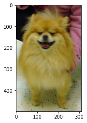

```python
rand_file=random.choice(img_data.filename)
rand_file
img=cv2.imread(str(train_path)+ "/"+str(rand_file))
img=cv2.cvtColor(img,cv2.COLOR_BGR2RGB)
plt.imshow(img)

img.shape
```

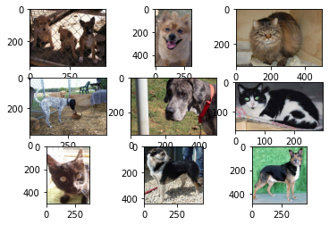

```python
for i in range(9):#show the first 9 images
    #define subplot
    plt.subplot(330 + 1 + i)
    img=cv2.imread(str(train_path)+ "/"+img_data.filename[i])
    img=cv2.cvtColor(img,cv2.COLOR_BGR2RGB)
    plt.imshow(img)
```

The plot above shows the first 9 cat and dog images in the loaded dataset.

The plot also shows that the images do not have the same dimensions and also some images are in portrait while some are in landscape.

# Normalization and Resizing

The next thing I did was to check the dimensions of the images.

## Check dimension of the images

```python
for i in range(9):
    rand_file=random.choice(img_data.filename)
    img=cv2.imread(str(train_path)+ "/"+str(rand_file))
    print(img.shape)
```

```
(375, 499, 3)
(308, 384, 3)
(239, 320, 3)
(500, 406, 3)
(466, 353, 3)
(375, 499, 3)
(359, 460, 3)
(400, 270, 3)
(349, 349, 3)
```

From the output above, it shows that the images do not have equal sizes. So the next thing to do is to make all the images to have a size of 350 *350* 3

```python
img_height=350
img_width=350
img_channel=3
```

# Train Test Split on Training Data

The data was split into a train and validation/development set using 30% of the data as the validation set

```python
from sklearn.model_selection import train_test_split
train,development=train_test_split(img_data,test_size = 0.3, random_state = 42)
print(train.shape)
print(development.shape)
```

```
(17500, 2)
(7500, 2)
```

# Class distribution in the train data

```python
train['category'].value_counts()
```

```
dog    8774
cat    8726
Name: category, dtype: int64
```

The class distribution in the training set shows an almost similar number of observations in both classes which is a good thing.

```python
train.head()
```

|  | filename | category |
| --- | --- | --- |
| 4913 | cat.12388.jpg | cat |
| 9338 | cat.4675.jpg | cat |
| 24211 | cat.2332.jpg | cat |
| 18791 | cat.7812.jpg | cat |
| 16066 | cat.12283.jpg | cat |

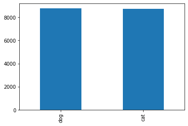

```python
train['category'].value_counts().plot(kind = 'bar')
```

The barplot shows that the data is balanced as both classes have almost the same number of observations.

# Model Fitting

```python
# import layers from keras
import tensorflow as tf
from tensorflow.keras.layers import Input,Conv2D,BatchNormalization,MaxPooling2D,Dense,Dropout,GlobalMaxPooling2D,Flatten
from tensorflow.keras.models import Model
from tensorflow.keras.callbacks import EarlyStopping,ModelCheckpoint
from tensorflow.keras.preprocessing.image import load_img
```

## Convolutional Neural Network

```python
i=Input((img_height,img_width,img_channel))
x=Conv2D(32,(3,3),activation='relu',padding='same')(i)
x=BatchNormalization()(x)
x=Conv2D(32,(3,3),activation='relu',padding='same')(x)
x=BatchNormalization()(x)
x=MaxPooling2D((2,2))(x)

x=Conv2D(64,(3,3),activation='relu',padding='same')(x)
x=BatchNormalization()(x)
x=Conv2D(64,(3,3),activation='relu',padding='same')(x)
x=BatchNormalization()(x)
x=MaxPooling2D((2,2))(x)

x=Conv2D(128,(3,3),activation='relu',padding='same')(x)
x=BatchNormalization()(x)
x=Conv2D(128,(3,3),activation='relu',padding='same')(x)
x=BatchNormalization()(x)
x=GlobalMaxPooling2D()(x)
x=Dropout(0.2)(x)
x=Flatten()(x)
x=Dense(2056,activation='relu')(x)
x=Dropout(0.2)(x)
x=Dense(2,activation='softmax')(x)

model=Model(i,x)
model.summary()
```

```
Model: "model"
_________________________________________________________________
Layer (type)                 Output Shape              Param #
=================================================================
input_1 (InputLayer)         [(None, 350, 350, 3)]     0
_________________________________________________________________
conv2d (Conv2D)              (None, 350, 350, 32)      896
_________________________________________________________________
batch_normalization (BatchNo (None, 350, 350, 32)      128
_________________________________________________________________
conv2d_1 (Conv2D)            (None, 350, 350, 32)      9248
_________________________________________________________________
batch_normalization_1 (Batch (None, 350, 350, 32)      128
_________________________________________________________________
max_pooling2d (MaxPooling2D) (None, 175, 175, 32)      0
_________________________________________________________________
conv2d_2 (Conv2D)            (None, 175, 175, 64)      18496
_________________________________________________________________
batch_normalization_2 (Batch (None, 175, 175, 64)      256
_________________________________________________________________
conv2d_3 (Conv2D)            (None, 175, 175, 64)      36928
_________________________________________________________________
batch_normalization_3 (Batch (None, 175, 175, 64)      256
_________________________________________________________________
max_pooling2d_1 (MaxPooling2 (None, 87, 87, 64)        0
_________________________________________________________________
conv2d_4 (Conv2D)            (None, 87, 87, 128)       73856
_________________________________________________________________
batch_normalization_4 (Batch (None, 87, 87, 128)       512
_________________________________________________________________
conv2d_5 (Conv2D)            (None, 87, 87, 128)       147584
_________________________________________________________________
batch_normalization_5 (Batch (None, 87, 87, 128)       512
_________________________________________________________________
global_max_pooling2d (Global (None, 128)               0
_________________________________________________________________
dropout (Dropout)            (None, 128)               0
_________________________________________________________________
flatten (Flatten)            (None, 128)               0
_________________________________________________________________
dense (Dense)                (None, 2056)              265224
_________________________________________________________________
dropout_1 (Dropout)          (None, 2056)              0
_________________________________________________________________
dense_1 (Dense)              (None, 2)                 4114
=================================================================
Total params: 558,138
Trainable params: 557,242
Non-trainable params: 896
_________________________________________________________________
```

The first model I created is a Convolutional Neural Network.

The first layer is a convolution layer with 32 kernels of size 3X3. Also, the input layer has the size of 350x350x3 in order to make all the input images have an equal size. The final layer has 4114 parameters.

# Model Optimization Technique

# Image Data Generator

An image data generator was then created on the train and validation data which would allow me augment the images in real-time during training of the model. This would improve on the robustness of the model as various transformations of the training image is used for model building.

The transformations done on the training images include:

1. Rotation of the axis
2. Normalization of the image pixel values
3. Zooming the images
4. Flipping the images
5. Adjusting of the brightness

# Image Data Generator for Train data

```python
train_data_generator=tf.keras.preprocessing.image.ImageDataGenerator(rotation_range=20,rescale=1/255,width_shift_range=0.1,
                                                                     height_shift_range=0.1,shear_range= 0.1,zoom_range=0.2,brightness_range = (0.1, 0.9),horizontal_flip=True)

train_data=train_data_generator.flow_from_dataframe(train,train_path,x_col='filename',y_col='category',
                                                    target_size=(img_height,img_width),batch_size=32)
```

```
Found 17500 validated image filenames belonging to 2 classes.
```

```python
train_data
```

```
<tensorflow.python.keras.preprocessing.image.DataFrameIterator at 0x7fe2d985c8d0>
```

# Image Data Generator for Development data

```python
development_data_generator=tf.keras.preprocessing.image.ImageDataGenerator(rescale=1/255)

development_data=development_data_generator.flow_from_dataframe(development,train_path,x_col='filename',y_col='category',
                                                    target_size=(img_height,img_width),batch_size=32)
```

```
Found 7500 validated image filenames belonging to 2 classes.
```

```python
development_data
```

```
<tensorflow.python.keras.preprocessing.image.DataFrameIterator at 0x7fe2d9af02d0>
```

# Demonstration of the Image Data Generator

```python
demo = train.sample(n = 1).reset_index(drop=True)
demo_gen_data = train_data_generator.flow_from_dataframe(demo,
                                                   train_path,
                                                   x_col = 'filename',
                                                   y_col = 'category',
                                                   target_size = (img_height,img_width),
                                                   batch_size=32)
```

```
Found 1 validated image filenames belonging to 1 classes.
```

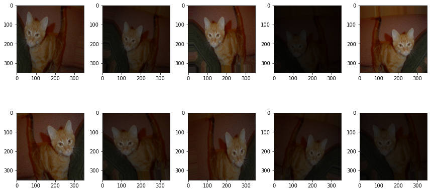

```python
plt.figure(figsize = (12, 12))
for i in range(0, 10):
    plt.subplot(4, 5, i+1)
    for x_batch, y_batch in demo_gen_data:
        img = x_batch[0]
        plt.imshow(img)
        break
plt.tight_layout()
```

The above plot shows the various augmented version of the cat image.

```python
callbacks=[EarlyStopping(monitor='val_loss',patience=2)] #Early Stopping
model.compile(loss='categorical_crossentropy',metrics=['accuracy'],optimizer='adam')
r=model.fit(train_data,validation_data=development_data,steps_per_epoch=train.shape[0]//32,batch_size=32,callbacks=callbacks,epochs=50)
```

The model was then fitted using the train data, and the validation data was also being used to assess the accuracy of the model at each run. The total number of epoch set was 50. However, to avoid overfitting issues, an early stop criteria was defined. The early stop criteria is the validation_loss, so if the validation loss cannot be improved on after 2 trials, the model would stop fitting.

# Loss and Accuracy Plot

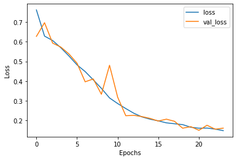

```python
plt.plot(r.history['loss'],label='loss')
plt.plot(r.history['val_loss'],label='val_loss')
plt.legend()
plt.ylabel('Loss')
plt.xlabel('Epochs')
plt.show()
```

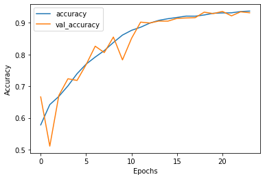

```python
plt.plot(r.history['accuracy'],label='accuracy')
plt.plot(r.history['val_accuracy'],label='val_accuracy')
plt.legend()
plt.ylabel('Accuracy')
plt.xlabel('Epochs')
plt.show()
```

Plots of the loss and accuracy for both the train and validation data is shown above. It show that the highest validation accuracy and lowest loss is when it was run 21 times.

# Artificial Neural Network

```python
i=Input((img_height,img_width,img_channel))
x=Dense(2,activation='relu')(i)
x=Dropout(0.2)(x)
x=Dense(2,activation='relu')(x)
x=Dropout(0.4)(x)
x=Flatten()(x)
x=Dense(2,activation='softmax')(x)

model2=Model(i,x)
model2.summary()
```

```
Model: "model_1"
_________________________________________________________________
Layer (type)                 Output Shape              Param #
=================================================================
input_2 (InputLayer)         [(None, 350, 350, 3)]     0
_________________________________________________________________
dense_2 (Dense)              (None, 350, 350, 2)       8
_________________________________________________________________
dropout_2 (Dropout)          (None, 350, 350, 2)       0
_________________________________________________________________
dense_3 (Dense)              (None, 350, 350, 2)       6
_________________________________________________________________
dropout_3 (Dropout)          (None, 350, 350, 2)       0
_________________________________________________________________
flatten_1 (Flatten)          (None, 245000)            0
_________________________________________________________________
dense_4 (Dense)              (None, 2)                 490002
=================================================================
Total params: 490,016
Trainable params: 490,016
Non-trainable params: 0
_________________________________________________________________
```

The second model I created was an Artificial Neural network. It has a total of 490002 parameters in the last layer.

```python
callbacks=[EarlyStopping(monitor='val_loss',patience=2)] #Early Stopping
model2.compile(loss='categorical_crossentropy',metrics=['accuracy'],optimizer='adam')
r2=model2.fit(train_data,validation_data=development_data,steps_per_epoch=train.shape[0]//32,batch_size=32,callbacks=callbacks,epochs=30)
```

# Loss and Accuracy Plot

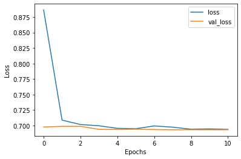

```python
plt.plot(r2.history['loss'],label='loss')
plt.plot(r2.history['val_loss'],label='val_loss')
plt.legend()
plt.ylabel('Loss')
plt.xlabel('Epochs')
plt.show()
```

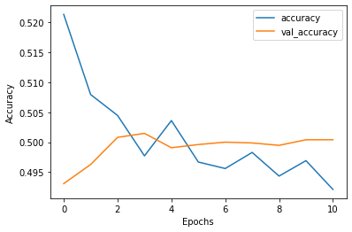

```python
plt.plot(r2.history['accuracy'],label='accuracy')
plt.plot(r2.history['val_accuracy'],label='val_accuracy')
plt.legend()
plt.ylabel('Accuracy')
plt.xlabel('Epochs')
plt.show()
```

The metric plot shows that this model is not a good fit as the best accuracy I attained on the validation set was around 50%. Also, the minimum loss was around 69%. This is very low when compared to the CNN model.

Looking at the results gotten from both models, it shows that the CNN model is better as it has a higher accuracy and a lower loss. As I already optimized the model by using a data generator at the beginning, the next thing I did was to apply all the preprocessing done on the unseen test data and then make predictions on the data.

# Making Predictions

## Test data Preprocessing (Unseen)

```python
# Loading of the test data
file_name = os.listdir(test_path)

test = pd.DataFrame({'filename': file_name})
```

```python
test.head()
```

|  | filename |
| --- | --- |
| 0 | 2728.jpg |
| 1 | 7367.jpg |
| 2 | 6033.jpg |
| 3 | 10294.jpg |
| 4 | 7946.jpg |

# Image Data Generator for test data (Unseen)

```python
test_data_generator=tf.keras.preprocessing.image.ImageDataGenerator(rescale=1/255)

test_data=test_data_generator.flow_from_dataframe(test,test_path,x_col='filename',y_col=None,class_mode=None,
                                                    target_size=(img_height,img_width),batch_size=32)
```

```
Found 12500 validated image filenames.
```

The image pixels on the test data was then mormalized using the rescale function.

# Predict

```python
pred = model.predict(test_data)

test['class_type']=np.argmax(pred,axis=1) #Change the predicted values from probabilities to class with highest probability
```

Using the CNN model, I then predicted the images on the test data. As the predicted values are probabilities, I then got the class by taking the class with the highest probability

```python
test['class_type'] = test['class_type'].replace({ 1: "dog", 0: "cat" })
test.head(10)
```

|  | filename | class_type |
| --- | --- | --- |
| 0 | 2728.jpg | dog |
| 1 | 7367.jpg | dog |
| 2 | 6033.jpg | dog |
| 3 | 10294.jpg | dog |
| 4 | 7946.jpg | cat |
| 5 | 11704.jpg | cat |
| 6 | 11507.jpg | dog |
| 7 | 7920.jpg | dog |
| 8 | 1243.jpg | dog |
| 9 | 10913.jpg | dog |

The next thing I then did was to convert the binary values to their class names for better interpretability.

## Plot first 10 predictions

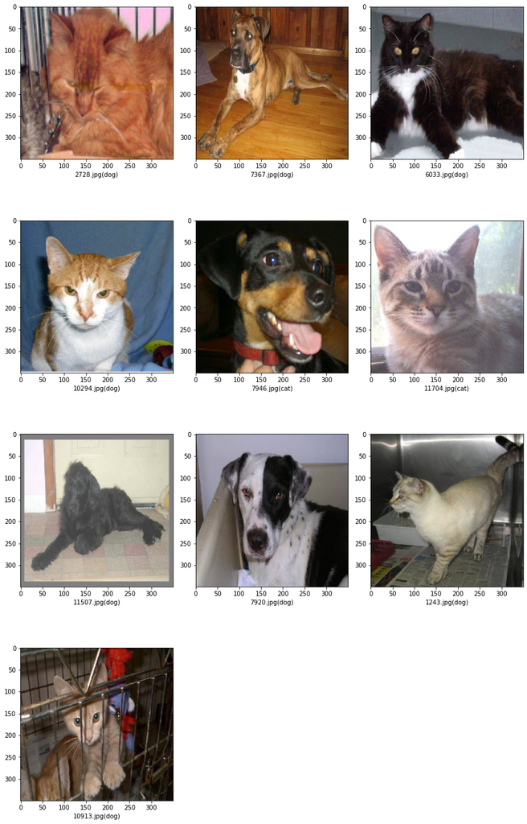

```python
plt.figure(figsize = (12,24))

for index, row in test.head(10).iterrows():
    filename = row['filename']
    category = row['class_type']
    img = load_img(str(test_path)+ "/" + filename,
                   target_size = (img_width, img_height))
    plt.subplot(5,3, index +1)
    plt.imshow(img)
    plt.xlabel(filename + '(' + "{}".format(category) + ")")

plt.tight_layout()
```

The first 10 predicted values of the unseen test data was then plotted. The above shows the image and on the x label shows the class that the model assigned to it.

From the result above, we can see that some images were classified correctly while some were not. As I cannot manually check all the images and the predicted classes, I would not be able to have an idea of the performance on this unseen data.

In conclusion, this assignment looks at using 2 different models to classify images as either cat or dogs. One of the challenges of this task was fitting my models and trying to optimize the model as the models took a long time to run and I also encountered crashes sometimes becuase the ram was used up.